# Correlations

## What parameters affect self-perceived speaking ability of patients?

Acoustic vowel duration ~ VAS

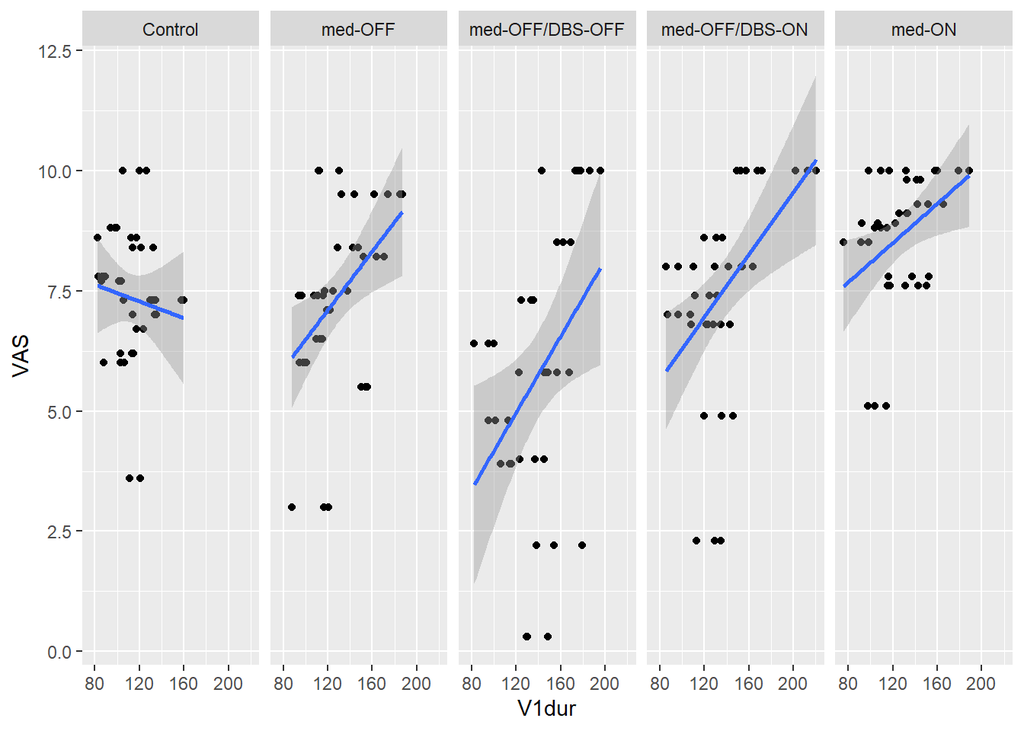

```r
ggplot(data_new, aes(x=V1dur, y=VAS)) +
  geom_point()+
  geom_smooth(method=lm)+
  facet_grid(.~med_con)
```

Calculate correlation coefficient between V1.dur and VAS

```r
## med-OFF
shapiro.test(data_medOFF$V1dur) # p = 0.07116
```

```
##
##  Shapiro-Wilk normality test
##
## data:  data_medOFF$V1dur
## W = 0.94814, p-value = 0.07116
```

```r
shapiro.test(data_medOFF$VAS) # p = 0.008463
```

```
##
##  Shapiro-Wilk normality test
##
## data:  data_medOFF$VAS
## W = 0.91961, p-value = 0.008463
```

```r
cor.test(data_medOFF$V1dur, data_medOFF$VAS, method = "spearman") ## r(37) = 0.42, p = 0.007857
```

```
##
##  Spearman's rank correlation rho
##
## data:  data_medOFF$V1dur and data_medOFF$VAS
## S = 5735.7, p-value = 0.007857
## alternative hypothesis: true rho is not equal to 0
## sample estimates:
##       rho
## 0.4194627
```

```r
## med-ON
shapiro.test(data_medON$V1dur) # p = 0.8247
```

```
##
##  Shapiro-Wilk normality test
##
## data:  data_medON$V1dur
## W = 0.98346, p-value = 0.8247
```

```r
shapiro.test(data_medON$VAS) # p = 5.054e-05
```

```
##
##  Shapiro-Wilk normality test
##
## data:  data_medON$VAS
## W = 0.83589, p-value = 5.054e-05
```

```r
cor.test(data_medON$V1dur, data_medON$VAS, method = "spearman") ## r(37) = 0.43, p = 0.006156
```

```
##
##  Spearman's rank correlation rho
##
## data:  data_medON$V1dur and data_medON$VAS
## S = 5621.5, p-value = 0.006156
## alternative hypothesis: true rho is not equal to 0
## sample estimates:
##       rho
## 0.4310216
```

```r
## DBS-ON
shapiro.test(data_DBSON$V1dur) # p = 0.05746
```

```
##
##  Shapiro-Wilk normality test
##
## data:  data_DBSON$V1dur
## W = 0.94538, p-value = 0.05746
```

```r
shapiro.test(data_DBSON$VAS) # p = 0.0002832
```

```
##
##  Shapiro-Wilk normality test
##
## data:  data_DBSON$VAS
## W = 0.86694, p-value = 0.0002832
```

```r
cor.test(data_DBSON$V1dur, data_DBSON$VAS, method = "spearman") ## r(37) = 0.56, p = 0.0002047
```

```
##
##  Spearman's rank correlation rho
##
## data:  data_DBSON$V1dur and data_DBSON$VAS
## S = 4339.7, p-value = 0.0002047
## alternative hypothesis: true rho is not equal to 0
## sample estimates:
##       rho
## 0.5607631
```

VAI ~ VAS

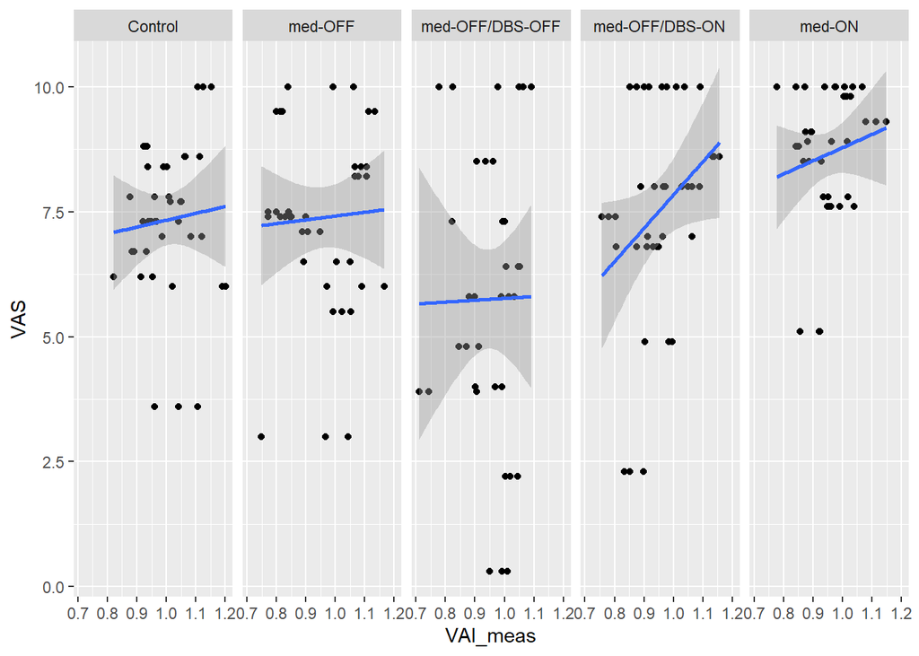

```r
ggplot(data_new, aes(x=VAI_meas, y=VAS)) +
  geom_point()+
  geom_smooth(method=lm)+
  facet_grid(.~med_con)
```

Calculate correlation coefficient between VAI and VAS

```r
## med-OFF
shapiro.test(data_medOFF$VAI_meas) # p = 0.0165
```

```
##
##  Shapiro-Wilk normality test
##
## data:  data_medOFF$VAI_meas
## W = 0.92884, p-value = 0.0165
```

```r
shapiro.test(data_medOFF$VAS) # p = 0.008463
```

```
##
##  Shapiro-Wilk normality test
##
## data:  data_medOFF$VAS
## W = 0.91961, p-value = 0.008463
```

```r
cor.test(data_medOFF$VAI_meas, data_medOFF$VAS, method = "spearman") ## r(37) = 0.07, n.s.
```

```
##
##  Spearman's rank correlation rho
##
## data:  data_medOFF$VAI_meas and data_medOFF$VAS
## S = 9201.3, p-value = 0.6778
## alternative hypothesis: true rho is not equal to 0
## sample estimates:
##        rho
## 0.06868931
```

```r
## med-ON
shapiro.test(data_medON$VAI_meas) # p = 0.8574
```

```
##
##  Shapiro-Wilk normality test
##
## data:  data_medON$VAI_meas
## W = 0.98449, p-value = 0.8574
```

```r
shapiro.test(data_medON$VAS) # p = 5.054e-05
```

```
##
##  Shapiro-Wilk normality test
##
## data:  data_medON$VAS
## W = 0.83589, p-value = 5.054e-05
```

```r
cor.test(data_medON$VAI_meas, data_medON$VAS, method = "spearman") ## r(37) = 0.17, n.s.
```

```
##
##  Spearman's rank correlation rho
##
## data:  data_medON$VAI_meas and data_medON$VAS
## S = 8235.4, p-value = 0.3111
## alternative hypothesis: true rho is not equal to 0
## sample estimates:
##       rho
## 0.1664614
```

```r
## DBS-ON
shapiro.test(data_DBSON$VAI_meas) # p = 0.8184
```

```
##
##  Shapiro-Wilk normality test
##
## data:  data_DBSON$VAI_meas
## W = 0.98327, p-value = 0.8184
```

```r
shapiro.test(data_DBSON$VAS) # p =0.0002832
```

```
##
##  Shapiro-Wilk normality test
##
## data:  data_DBSON$VAS
## W = 0.86694, p-value = 0.0002832
```

```r
cor.test(data_DBSON$VAI_meas, data_DBSON$VAS, method = "spearman") ## r(37) = 0.37, p = 0.02161
```

```
##
##  Spearman's rank correlation rho
##
## data:  data_DBSON$VAI_meas and data_DBSON$VAS
## S = 6255.5, p-value = 0.02161
## alternative hypothesis: true rho is not equal to 0
## sample estimates:
##       rho
## 0.3668544
```

TB DUR ~ VAS

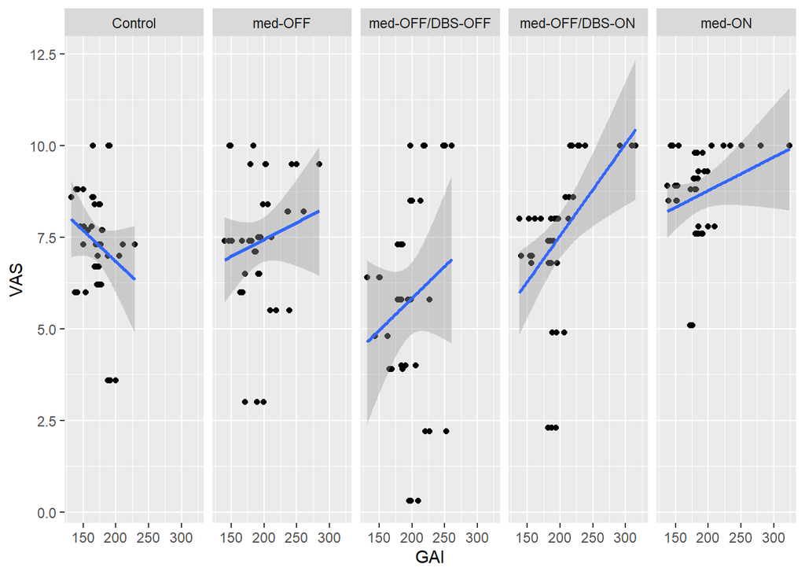

```r
ggplot(data_new, aes(x=GAI, y=VAS)) +
  geom_point()+
  geom_smooth(method=lm)+
  facet_grid(.~med_con)
```

Calculate correlation coefficient between TB DUR and VAS

```r
## med-OFF
shapiro.test(data_medOFF$GAI) # p = 0.1508
```

```
##
##  Shapiro-Wilk normality test
##
## data:  data_medOFF$GAI
## W = 0.95782, p-value = 0.1508
```

```r
shapiro.test(data_medOFF$VAS) # p = 0.008463
```

```
##
##  Shapiro-Wilk normality test
##
## data:  data_medOFF$VAS
## W = 0.91961, p-value = 0.008463
```

```r
cor.test(data_medOFF$GAI, data_medOFF$VAS, method = "spearman") ## r(37) = 0.17, n.s.
```

```
##
##  Spearman's rank correlation rho
##
## data:  data_medOFF$GAI and data_medOFF$VAS
## S = 8215, p-value = 0.3051
## alternative hypothesis: true rho is not equal to 0
## sample estimates:
##       rho
## 0.1685178
```

```r
## med-ON
shapiro.test(data_medON$GAI) # p = 5.182e-05
```

```
##
##  Shapiro-Wilk normality test
##
## data:  data_medON$GAI
## W = 0.83636, p-value = 5.182e-05
```

```r
shapiro.test(data_medON$VAS) # p = 5.054e-05
```

```
##
##  Shapiro-Wilk normality test
##
## data:  data_medON$VAS
## W = 0.83589, p-value = 5.054e-05
```

```r
cor.test(data_medON$GAI, data_medON$VAS, method = "spearman") ## r(37) = 0.25, n.s.
```

```
##
##  Spearman's rank correlation rho
##
## data:  data_medON$GAI and data_medON$VAS
## S = 7417.6, p-value = 0.126
## alternative hypothesis: true rho is not equal to 0
## sample estimates:
##       rho
## 0.2492322
```

```r
## DBS-ON
shapiro.test(data_DBSON$GAI) # p = 0.0004434
```

```
##
##  Shapiro-Wilk normality test
##
## data:  data_DBSON$GAI
## W = 0.87451, p-value = 0.0004434
```

```r
shapiro.test(data_DBSON$VAS) # p = 0.0002832
```

```
##
##  Shapiro-Wilk normality test
##
## data:  data_DBSON$VAS
## W = 0.86694, p-value = 0.0002832
```

```r
cor.test(data_DBSON$GAI, data_DBSON$VAS, method = "spearman") ## r(37) = 0.61, p = 3.363e-05
```

```
##
##  Spearman's rank correlation rho
##
## data:  data_DBSON$GAI and data_DBSON$VAS
## S = 3824.9, p-value = 3.363e-05
## alternative hypothesis: true rho is not equal to 0
## sample estimates:
##       rho
## 0.6128626
```

UPDRS ~ VAS

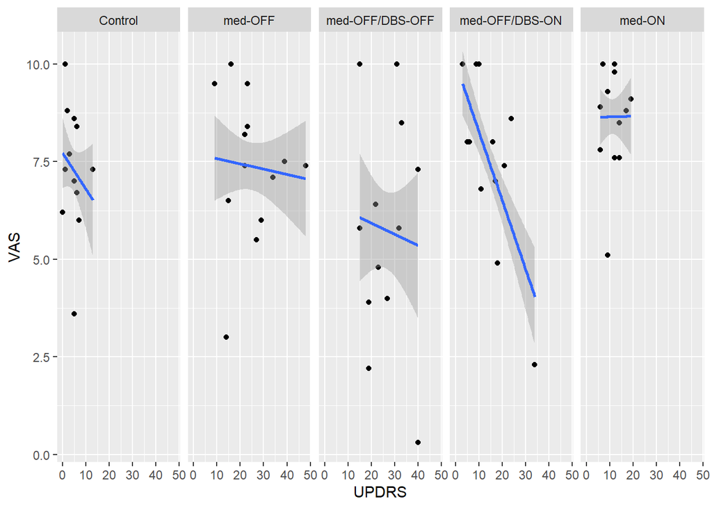

```r
ggplot(data_new, aes(x=UPDRS, y=VAS)) +
  geom_point()+
  geom_smooth(method=lm)+
  facet_grid(.~med_con)
```

Calculate correlation coefficient between UPDRS and VAS

```r
## med-OFF
shapiro.test(data_medOFF$UPDRS) # p = 0.0153
```

```
##
##  Shapiro-Wilk normality test
##
## data:  data_medOFF$UPDRS
## W = 0.92781, p-value = 0.0153
```

```r
shapiro.test(data_medOFF$VAS) # p = 0.008463
```

```
##
##  Shapiro-Wilk normality test
##
## data:  data_medOFF$VAS
## W = 0.91961, p-value = 0.008463
```

```r
cor.test(data_medOFF$UPDRS, data_medOFF$VAS, method = "spearman") ## r(37) = -0.16, n.s.
```

```
##
##  Spearman's rank correlation rho
##
## data:  data_medOFF$UPDRS and data_medOFF$VAS
## S = 11490, p-value = 0.3215
## alternative hypothesis: true rho is not equal to 0
## sample estimates:
##        rho
## -0.1629834
```

```r
## med-ON
shapiro.test(data_medON$UPDRS) # p = 0.004
```

```
##
##  Shapiro-Wilk normality test
##
## data:  data_medON$UPDRS
## W = 0.90886, p-value = 0.004
```

```r
shapiro.test(data_medON$VAS) # p = 5.054e-05
```

```
##
##  Shapiro-Wilk normality test
##
## data:  data_medON$VAS
## W = 0.83589, p-value = 5.054e-05
```

```r
cor.test(data_medON$UPDRS, data_medON$VAS, method = "spearman") ## r(37) = -0.17, n.s.
```

```
##
##  Spearman's rank correlation rho
##
## data:  data_medON$UPDRS and data_medON$VAS
## S = 11580, p-value = 0.295
## alternative hypothesis: true rho is not equal to 0
## sample estimates:
##        rho
## -0.1720295
```

```r
## DBS-ON
shapiro.test(data_DBSON$UPDRS) # p = 0.006692
```

```
##
##  Shapiro-Wilk normality test
##
## data:  data_DBSON$UPDRS
## W = 0.91629, p-value = 0.006692
```

```r
shapiro.test(data_DBSON$VAS) # p = 0.0002832
```

```
##
##  Shapiro-Wilk normality test
##
## data:  data_DBSON$VAS
## W = 0.86694, p-value = 0.0002832
```

```r
cor.test(data_DBSON$UPDRS, data_DBSON$VAS, method = "spearman") ## r(37) = -0.58, p = 0.0001219
```

```
##
##  Spearman's rank correlation rho
##
## data:  data_DBSON$UPDRS and data_DBSON$VAS
## S = 15577, p-value = 0.0001219
## alternative hypothesis: true rho is not equal to 0
## sample estimates:
##        rho
## -0.5766375
```

axial ~ VAS

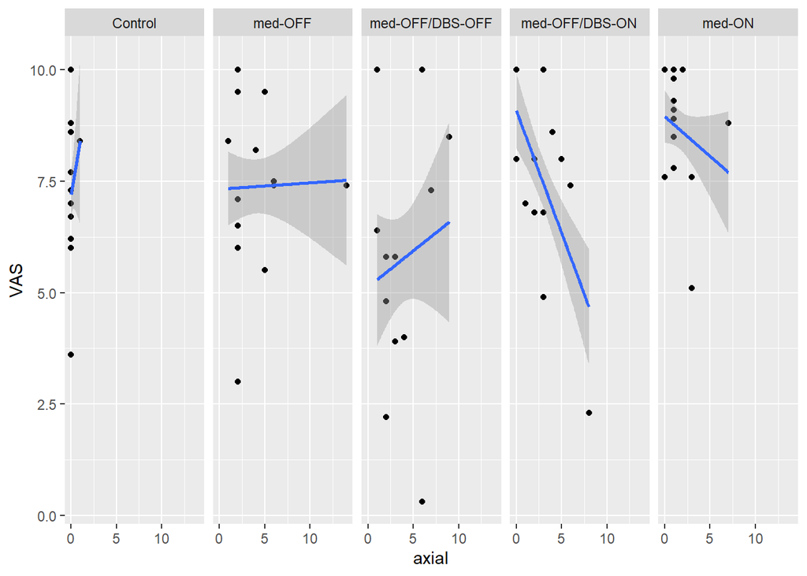

```r
ggplot(data_new, aes(x=axial, y=VAS)) +
  geom_point()+
  geom_smooth(method=lm)+
  facet_grid(.~med_con)
```

Calculate correlation coefficient between axial subscores and VAS

```r
## med-OFF
shapiro.test(data_medOFF$axial) # p = 1.661e-07
```

```
##
##  Shapiro-Wilk normality test
##
## data:  data_medOFF$axial
## W = 0.70724, p-value = 1.661e-07
```

```r
shapiro.test(data_medOFF$VAS) # p = 0.008463
```

```
##
##  Shapiro-Wilk normality test
##
## data:  data_medOFF$VAS
## W = 0.91961, p-value = 0.008463
```

```r
cor.test(data_medOFF$axial, data_medOFF$VAS, method = "spearman") ## r(37) = -0.04, n.s.
```

```
##
##  Spearman's rank correlation rho
##
## data:  data_medOFF$axial and data_medOFF$VAS
## S = 10268, p-value = 0.8125
## alternative hypothesis: true rho is not equal to 0
## sample estimates:
##         rho
## -0.03923789
```

```r
## med-ON
shapiro.test(data_medON$axial) # p = 9.958e-08
```

```
##
##  Shapiro-Wilk normality test
##
## data:  data_medON$axial
## W = 0.69356, p-value = 9.958e-08
```

```r
shapiro.test(data_medON$VAS) # p = 5.054e-05
```

```
##
##  Shapiro-Wilk normality test
##
## data:  data_medON$VAS
## W = 0.83589, p-value = 5.054e-05
```

```r
cor.test(data_medON$axial, data_medON$VAS, method = "spearman") ## r(37) = -0.28, n.s.
```

```
##
##  Spearman's rank correlation rho
##
## data:  data_medON$axial and data_medON$VAS
## S = 12682, p-value = 0.08018
## alternative hypothesis: true rho is not equal to 0
## sample estimates:
##        rho
## -0.2836089
```

```r
## DBS-ON
shapiro.test(data_DBSON$axial) # p = 0.003841
```

```
##
##  Shapiro-Wilk normality test
##
## data:  data_DBSON$axial
## W = 0.90827, p-value = 0.003841
```

```r
shapiro.test(data_DBSON$VAS) # p = 0.0002832
```

```
##
##  Shapiro-Wilk normality test
##
## data:  data_DBSON$VAS
## W = 0.86694, p-value = 0.0002832
```

```r
cor.test(data_DBSON$axial, data_DBSON$VAS, method = "spearman") ## r(37) = -0.43, p = 0.005977
```

```
##
##  Spearman's rank correlation rho
##
## data:  data_DBSON$axial and data_DBSON$VAS
## S = 14152, p-value = 0.005977
## alternative hypothesis: true rho is not equal to 0
## sample estimates:
##        rho
## -0.4323944
```

## Correlations OFF to OFF change

Reported under section 10.2.4.

Combine data frames and subset for relevant conditions

```r
data_PD <- filter(data_new, med_con != c('Control'))
data_PD <- merge(data_PD, LEDD, by="speaker")

data_medOFF <-  filter(data_PD, med_con %in% c('med-OFF'))
data_DBSOFF <-  filter(data_PD, med_con %in% c('med-OFF/DBS-OFF'))
```

Calculate means per condition

```r
medOFF_avgs <- data_medOFF %>%
  group_by(speaker) %>%
  summarise(UPDRS_medOFF = mean(UPDRS, na.rm = T),
            axial_medOFF = mean(axial, na.rm = T),
            rigid_medOFF = mean(rigid, na.rm = T),
            brady_medOFF = mean(brady, na.rm = T),
            PIGD_medOFF = mean(PIGD, na.rm = T),

            GAI_medOFF = mean(GAI, na.rm = T),
            PVEL_medOFF = mean(PVEL, na.rm = T),
            DISP_medOFF = mean(DISP, na.rm = T),

            LEDD_medOFF = mean(LEDD_preop, na.rm = T),
            agonists_medOFF = mean(Agonists_preop, na.rm = T),
            time_agonist_medOFF = mean(last_agonist_preop, na.rm = T),
            time_visits = mean(Time_preop_postop))

DBSOFF_avgs <- data_DBSOFF  %>%
  group_by(speaker) %>%
  summarise(UPDRS_DBSOFF = mean(UPDRS, na.rm = T),
            axial_DBSOFF = mean(axial, na.rm = T),
            rigid_DBSOFF = mean(rigid, na.rm = T),
            brady_DBSOFF = mean(brady, na.rm = T),
            PIGD_DBSOFF = mean(PIGD, na.rm = T),

            GAI_DBSOFF = mean(GAI, na.rm = T),
            PVEL_DBSOFF = mean(PVEL, na.rm = T),
            DISP_DBSOFF = mean(DISP, na.rm = T),

            LEDD_DBSOFF = mean(LEDD_postop, na.rm = T),
            agonists_DBSOFF = mean(Agonists_postop, na.rm = T),
            time_agonist_DBSOFF = mean(last_agonist_postop, na.rm = T))

data_change <- inner_join(medOFF_avgs, DBSOFF_avgs, by= c("speaker"))
```

Calculate absolute and percentage change

```r
data_change$UPDRS_abs <- (data_change$UPDRS_medOFF - data_change$UPDRS_DBSOFF) * -1
data_change$UPDRS_perc <- (data_change$UPDRS_medOFF - data_change$UPDRS_DBSOFF)/data_change$UPDRS_medOFF * 100

data_change$axial_abs <- (data_change$axial_medOFF - data_change$axial_DBSOFF) * -1
data_change$axial_perc <- (data_change$axial_medOFF - data_change$axial_DBSOFF)/data_change$axial_medOFF * 100

data_change$brady_abs <- (data_change$brady_medOFF - data_change$brady_DBSOFF) * -1
data_change$brady_perc <- (data_change$brady_medOFF - data_change$brady_DBSOFF)/data_change$brady_medOFF * 100

data_change$PIGD_abs <- (data_change$PIGD_medOFF - data_change$PIGD_DBSOFF) * -1
data_change$PIGD_perc <- (data_change$PIGD_medOFF - data_change$PIGD_DBSOFF)/data_change$PIGD_medOFF * 100

data_change$DISP_abs <- (data_change$DISP_medOFF - data_change$DISP_DBSOFF) * -1
data_change$DISP_perc <- (data_change$DISP_medOFF - data_change$DISP_DBSOFF)/data_change$DISP_medOFF * 100

data_change$PVEL_abs <- (data_change$PVEL_medOFF - data_change$PVEL_DBSOFF) * -1
data_change$PVEL_perc <- (data_change$PVEL_medOFF - data_change$PVEL_DBSOFF)/data_change$PVEL_medOFF * 100

data_change$LEDD_abs <- (data_change$LEDD_medOFF - data_change$LEDD_DBSOFF) * -1
data_change$LEDD_perc <- (data_change$LEDD_medOFF - data_change$LEDD_DBSOFF)/data_change$LEDD_medOFF * 100

data_change$agonists_abs <- (data_change$agonists_medOFF - data_change$agonists_DBSOFF) * -1
data_change$agonists_perc <- (data_change$agonists_medOFF - data_change$agonists_DBSOFF)/data_change$agonists_medOFF * 100
```

Correlations

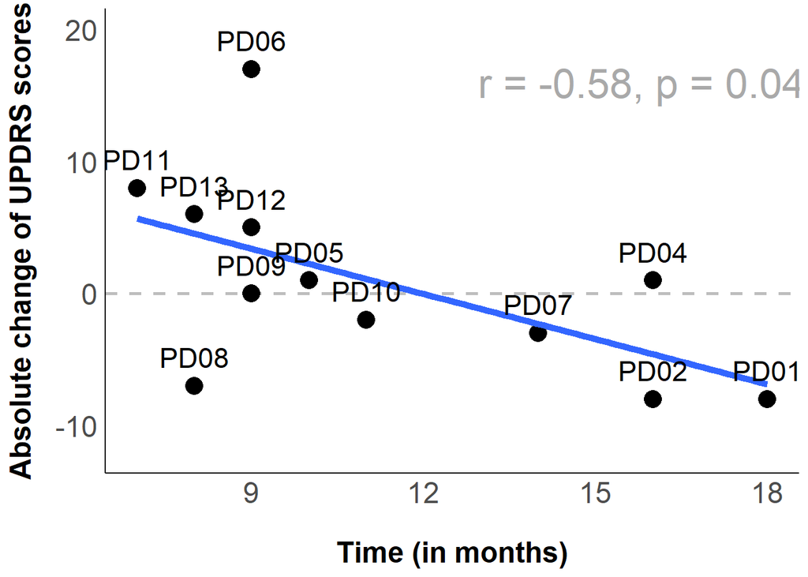

```r
ggplot(data_change, aes(x=time_visits, y=UPDRS_abs))+
  geom_hline(yintercept=0, linetype="dashed", color = "gray", size=1)+
  geom_point(size = 5)+
  geom_smooth(method=lm, se=FALSE, size = 2)+
  geom_text(aes(label = speaker), vjust = -.9, size = 6)+
  annotate("text", x = 16, y = 16, label = "r = -0.58, p = 0.047", size = 9, color = "darkgray")+
  theme_classic() +
  ylab("Absolute change of UPDRS scores")+
  xlab("Time (in months)")+
  ylim(-12,20)+
  theme(axis.text.x = element_text(size = 18),
        axis.text.y = element_text(size = 18)) +
  theme(axis.ticks.x = element_blank(),
        axis.ticks.y = element_blank())+
  theme(axis.title.y = element_text(face = 'bold', size = 18, margin = margin(r = 12)))+
  theme(axis.title.x = element_text(face = 'bold', size = 18, margin = margin(t = 20)))
```

```r
shapiro.test(data_change$time_visits) # p = 0.06089
```

```
##
##  Shapiro-Wilk normality test
##
## data:  data_change$time_visits
## W = 0.86758, p-value = 0.06089
```

```r
shapiro.test(data_change$UPDRS_abs) # p = 0.4317
```

```
##
##  Shapiro-Wilk normality test
##
## data:  data_change$UPDRS_abs
## W = 0.93463, p-value = 0.4317
```

```r
## TIME since first visit and absolute UPDRS change
cor.test(data_change$time_visits, data_change$UPDRS_abs, method = "pearson") #  r = 0.5813031, p-value = 0.04744
```

```
##
##  Pearson's product-moment correlation
##
## data:  data_change$time_visits and data_change$UPDRS_abs
## t = -2.2592, df = 10, p-value = 0.04744
## alternative hypothesis: true correlation is not equal to 0
## 95 percent confidence interval:
##  -0.86622327 -0.01110678
## sample estimates:
##        cor
## -0.5813031
```

Change in AGONISTS ~ CHANGE in TB AMPLITUDE

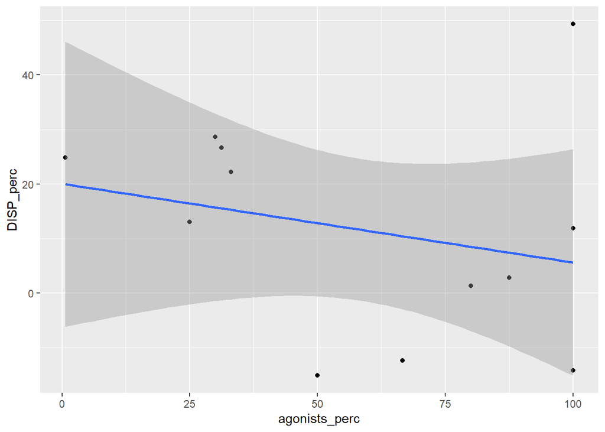

```r
ggplot(data_change, aes(x=agonists_perc, y=DISP_perc)) +
  geom_point()+
  geom_smooth(method=lm)
```

```r
shapiro.test(data_change$agonists_perc) # p = 0.1761
```

```
##
##  Shapiro-Wilk normality test
##
## data:  data_change$agonists_perc
## W = 0.90351, p-value = 0.1761
```

```r
shapiro.test(data_change$DISP_perc) # p = 0.5628
```

```
##
##  Shapiro-Wilk normality test
##
## data:  data_change$DISP_perc
## W = 0.94481, p-value = 0.5628
```

```r
cor.test(data_change$DISP_perc, data_change$agonists_perc, method = "pearson") ## r = -0.25, n.s.
```

```
##
##  Pearson's product-moment correlation
##
## data:  data_change$DISP_perc and data_change$agonists_perc
## t = -0.82215, df = 10, p-value = 0.4302
## alternative hypothesis: true correlation is not equal to 0
## 95 percent confidence interval:
##  -0.7213546  0.3766750
## sample estimates:
##        cor
## -0.2516205
```

Change in UPDRS ~ CHANGE in TB AMPLITUDE

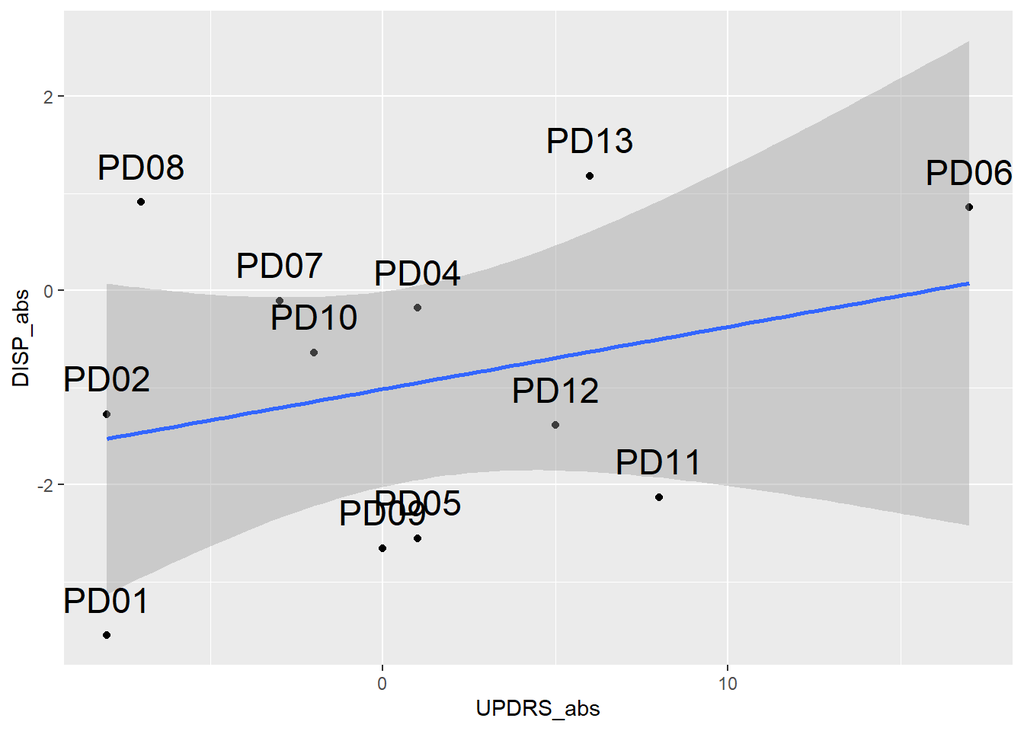

```r
ggplot(data_change, aes(x=UPDRS_abs, y=DISP_abs)) +
  geom_point()+
  geom_smooth(method=lm)+
    geom_text(aes(label = speaker), vjust = -.9, size = 6)
```

```r
shapiro.test(data_change$UPDRS_perc) # p = 0.1191
```

```
##
##  Shapiro-Wilk normality test
##
## data:  data_change$UPDRS_perc
## W = 0.89035, p-value = 0.1191
```

```r
shapiro.test(data_change$DISP_perc) # p = 0.5628
```

```
##
##  Shapiro-Wilk normality test
##
## data:  data_change$DISP_perc
## W = 0.94481, p-value = 0.5628
```

```r
cor.test(data_change$DISP_perc, data_change$UPDRS_perc, method = "pearson") ## r = 0.47, n.s.
```

```
##
##  Pearson's product-moment correlation
##
## data:  data_change$DISP_perc and data_change$UPDRS_perc
## t = 1.6863, df = 10, p-value = 0.1226
## alternative hypothesis: true correlation is not equal to 0
## 95 percent confidence interval:
##  -0.1416052  0.8223649
## sample estimates:
##       cor
## 0.4705356
```

Change in axial ~ CHANGE in TB AMPLITUDE

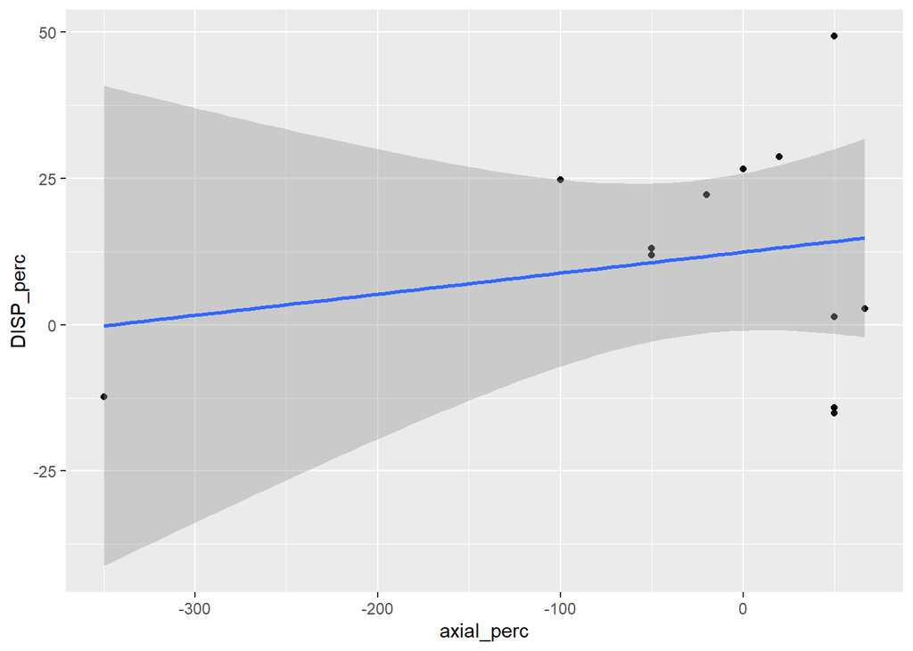

```r
ggplot(data_change, aes(x=axial_perc, y=DISP_perc)) +
  geom_point()+
  geom_smooth(method=lm)
```

```r
shapiro.test(data_change$axial_perc) # p = 0.001338
```

```
##
##  Shapiro-Wilk normality test
##
## data:  data_change$axial_perc
## W = 0.72052, p-value = 0.001338
```

```r
shapiro.test(data_change$DISP_perc) # p = 0.5628
```

```
##
##  Shapiro-Wilk normality test
##
## data:  data_change$DISP_perc
## W = 0.94481, p-value = 0.5628
```

```r
cor.test(data_change$DISP_perc, data_change$axial_perc, method = "spearman") ## r = -0.16, n.s.
```

```
##
##  Spearman's rank correlation rho
##
## data:  data_change$DISP_perc and data_change$axial_perc
## S = 332.91, p-value = 0.6105
## alternative hypothesis: true rho is not equal to 0
## sample estimates:
##        rho
## -0.1640244
```